# GE461 Homework 1

Efe Tarhan 22002840, Hande Yaylalı 21902986

2024-03-15

## Introduction

Data analysis and machine learning are two of the most important abilities for engineers today. Using techniques learned in the GE461 course, this report will analyze and use regression models to a dataset containing features about a team’s baseball games over the period of a season. This work is being performed to discover how the attendance rate of the matches is influenced due to some parameters. The study begins by examining the dataset in terms of statistical relations between features, plots, and chi-square tests. The analyses are followed by directives for meaningful observations. Following the analysis, the data will be utilized to develop regression models. The performances of all of these models are evaluated and compared.

## Analysis - Data Description & Analysis

The dataset that has been used for this project contains information about the 81 home plays of the baseball team The Dodgers in 2012. Each play data in the dataset has

- **Month**: A categorical value indicating the month that the game has been played,
- **Day**: A numerical value indicating the number of the day in the corresponding month,
- **Day of Week**: A categorical value consisting of the names of the days of the week.
- **Attendance**: A numerical feature consisting of number people attended to the event
- **Opponent**: A categorical indicator that consists of names of the opponent teams like “Pirates”, “Giants” and “Padres”,
- **Temperature:** A numerical feature consisting of temperature values ,
- **Skies**: A binary indicator of the weather with labels “Clear” and “Cloudy”,
- **Part of the day (day or night)**: A binary indicator of the part of the day with labels “Day” and “Night” ,
- **Cap**: A binary feature with labels “YES” and “NO”,
- **Shirt**: A binary feature with labels “YES” and “NO”,
- **Fireworks**: A binary feature with labels “YES” and “NO”,
- **Bobblehead**: A binary feature with labels “YES” and “NO” ,

These attributes or column headers can also be accessed by using the following code snippet that connects the database to R and extract the column headers:

```r
library(RSQLite)
con <-dbConnect(SQLite(), "dodgers.sqlite")
dbListFields(con, "events")
```

```
##  [1] "month"       "day"         "attend"      "day_of_week" "opponent"
##  [6] "temp"        "skies"       "day_night"   "cap"         "shirt"
## [11] "fireworks"   "bobblehead"
```

The first 5 rows of the dataset is shown below where the data type of each feature can be examined according to the descriptions provided above.

```r
d0 <- dbReadTable(con,"events");
head(d0,5)
```

```
##   month day attend day_of_week opponent temp  skies day_night cap shirt
## 1   APR  10  56000     Tuesday  Pirates   67  Clear       Day  NO    NO
## 2   APR  11  29729   Wednesday  Pirates   58 Cloudy     Night  NO    NO
## 3   APR  12  28328    Thursday  Pirates   57 Cloudy     Night  NO    NO
## 4   APR  13  31601      Friday   Padres   54 Cloudy     Night  NO    NO
## 5   APR  14  46549    Saturday   Padres   57 Cloudy     Night  NO    NO
##   fireworks bobblehead
## 1        NO         NO
## 2        NO         NO
## 3        NO         NO
## 4       YES         NO
## 5        NO         NO
```

```r
dbDisconnect(con)
```

The dataset will be analyzed in terms of its statistical properties and distribution of the features inside the dataset in an aim to understand the implicit features that may be effective on the decision of choosing a proper model for data fitting and prediction. The statistical properties of the dataset, i.e. the class frequencies for the categorical features and min, max, median upper and lower quartile values of the dataset are displayed by using the “summary()” function in R.

Before creating the summary of the dataset the temperature values are converted from Fahrenheit to Centigrade because of the readers convenience in working with European system.

```r
# d0$month %>% unique()
# d0$day_of_week %>% unique()
d <- d0 %>%
  mutate(month = factor(month, levels = c("APR", "MAY", "JUN", "JUL", "AUG", "SEP", "OCT")),
         day_of_week = factor(day_of_week, levels = c("Monday", "Tuesday", "Wednesday", "Thursday", "Friday", "Saturday", "Sunday")),
         temp = (temp-32)*5/9) %>%
  mutate(across(where(is.character), factor))
summary(d)
```

```
##  month         day            attend         day_of_week      opponent
##  APR:12   Min.   : 1.00   Min.   :24312   Monday   :12   Giants   : 9
##  MAY:18   1st Qu.: 8.00   1st Qu.:34493   Tuesday  :13   Padres   : 9
##  JUN: 9   Median :15.00   Median :40284   Wednesday:12   Rockies  : 9
##  JUL:12   Mean   :16.14   Mean   :41040   Thursday : 5   Snakes   : 9
##  AUG:15   3rd Qu.:25.00   3rd Qu.:46588   Friday   :13   Cardinals: 7
##  SEP:12   Max.   :31.00   Max.   :56000   Saturday :13   Brewers  : 4
##  OCT: 3                                   Sunday   :13   (Other)  :34
##       temp          skies    day_night   cap     shirt    fireworks bobblehead
##  Min.   :12.22   Clear :62   Day  :15   NO :79   NO :78   NO :67    NO :70
##  1st Qu.:19.44   Cloudy:19   Night:66   YES: 2   YES: 3   YES:14    YES:11
##  Median :22.78
##  Mean   :22.86
##  3rd Qu.:26.11
##  Max.   :35.00
##
```

Besides simple frequencies, the given numbers does not provide significant and intuitive information about the trends and patterns that the data contain.For example, the average attendance rate is 41040 individuals, while the minimum number of attendees is 24312 and the highest number of attendees is 56000, which is the stadium’s full capacity. Any significant observation cannot be done with these numbers on the feature of dataset. 2<sup>nd</sup> order statistics and cross statistics between the features with visualization can develop further information.

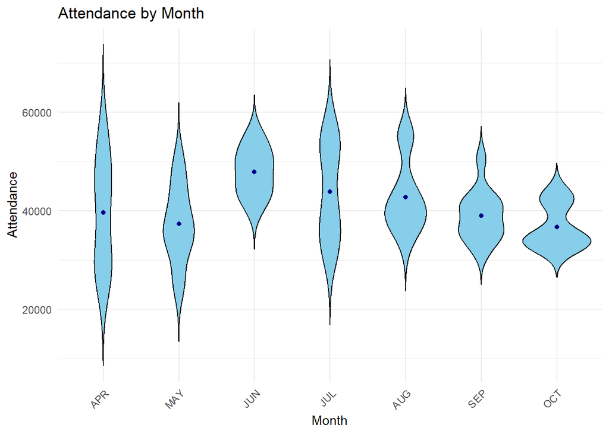

```r
ggplot(d, aes(x = month, y = attend)) +
  geom_violin(trim = FALSE, fill = "skyblue", color = "black") +
  stat_summary(fun = mean, geom = "point", aes(group = month), color = "darkblue") +
  theme_minimal() +
  labs(title = "Attendance by Month",
       x = "Month",
       y = "Attendance") +
  theme(axis.text.x = element_text(angle = 45, hjust = 1))
```

As it can be observed, the dark blue points on the graph indicate the mean of the given month whereas the width of the violin plot shows the data frequency around a given attendance. It can be seen from the plots that the average monthly attendance levels rise in June, July and August which are the summer months.Yet, each number of attendance results in different patterns of frequency of the data.

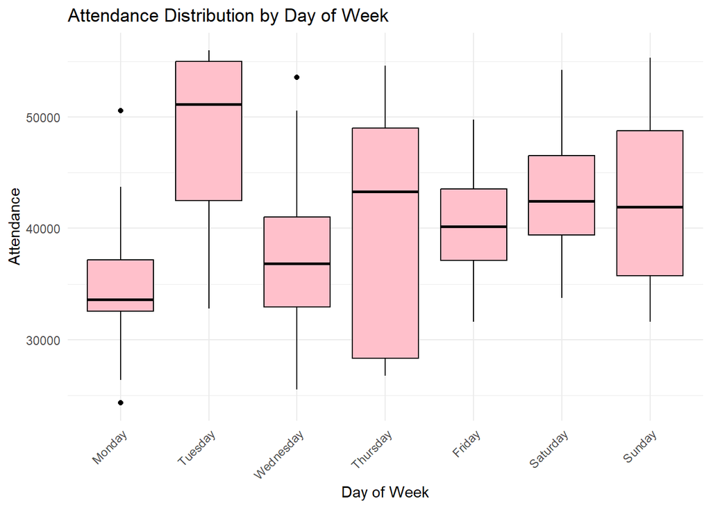

```r
ggplot(d, aes(x = day_of_week, y = attend)) +
  geom_boxplot(fill = "pink", color = "black") +
  theme_minimal() +
  labs(title = "Attendance Distribution by Day of Week",
       x = "Day of Week",
       y = "Attendance") +
  theme(axis.text.x = element_text(angle = 45, hjust = 1))
```

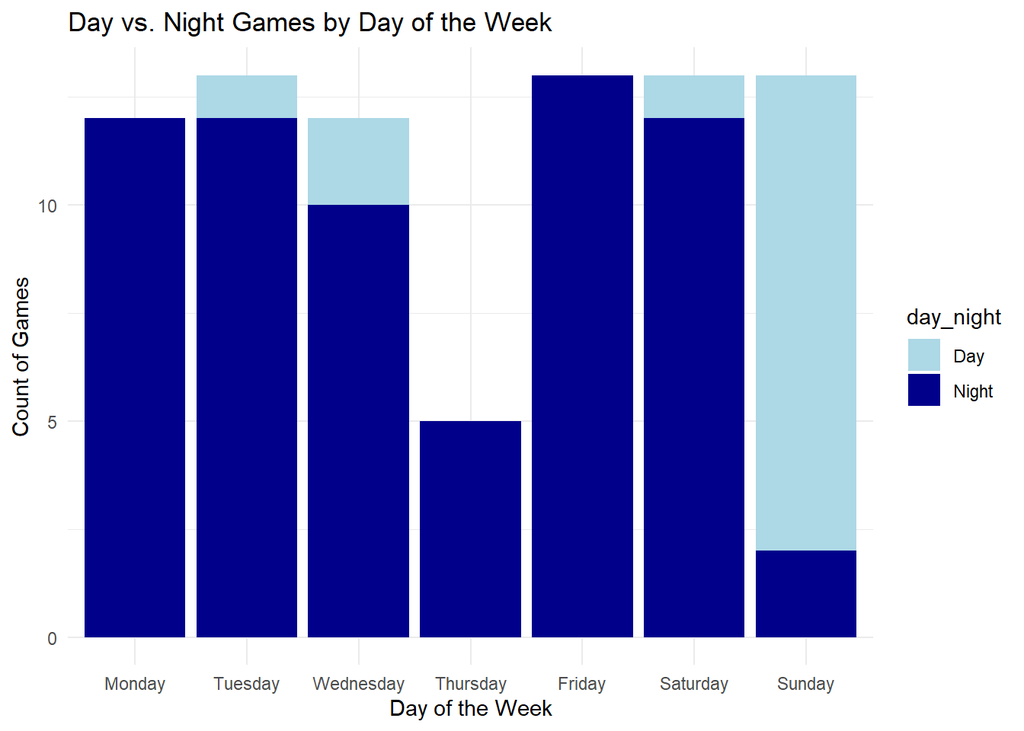

```r
ggplot(data = d, aes(x = day_of_week, fill = day_night)) +
  geom_bar(position = "stack") +
  labs(title = "Day vs. Night Games by Day of the Week", x = "Day of the Week", y = "Count of Games") +
  theme_minimal() +
  scale_fill_manual(values = c("Day" = "lightblue", "Night" = "darkblue"))
```

The bar chart illustrates that games are mainly held at evenings, but, Sunday is being the exception as hosting most of the games during daytime. This is acceptable given that weekdays may keep individuals occupied during the daytime. For this reason, only during weekday nights, individuals could attend the game. A possible relationship between temperature and number of attendance can be investigated by fitting a function to the density of data points for corresponding temperatures. The line is fitted to the plot using a local curve fitting algorithm called “loess” algorithm that can be used for exploring data better compared to polynomial fitting techniques.

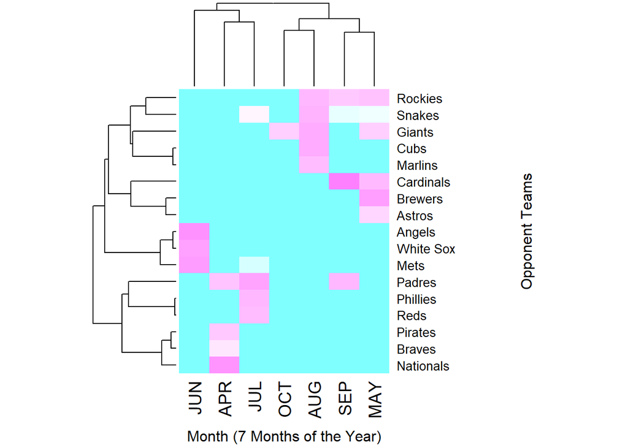

```r
  data_heatmap <- xtabs(attend ~ opponent + month, d)
  heatmap(data_heatmap, margins = c(5, 10), col = cm.colors(100), scale = "none", xlab = "Month (7 Months of the Year)", ylab = "Opponent Teams")
```

If any correlations exist between two characteristics, the heatmap would indicate them. The month data is shown with the opponent data using a heatmap. As the hue of pink darkens, it indicates that more data is observed in that region. Thus, in August, spectators tend to attend games with the Rockies, Snakes, Giants, Cubs, and Marlins. However, heatmap do not reveal important relationship in this scenerio.

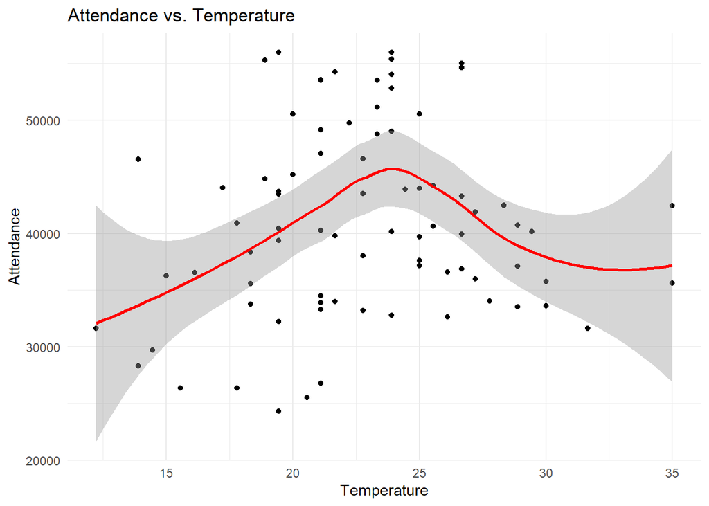

```r
  ggplot(d, aes(x = temp, y = attend)) +
  geom_point(color = "black") +
  geom_smooth(formula = y ~ x, method = "loess", color = "red") +
  labs(title = "Attendance vs. Temperature", x = "Temperature", y = "Attendance") +
  theme_minimal()
```

As it can be seen there is a nonlinear relationship between the feature temperature and the attendance amounts. To find the linear relationship between the temperature and attendance the variable must be transformed.

There are 4 features (“cap”, “shirt”, “bobblehead”, “fireworks”) that can be considered in the same category of objects or features of the game. There can be high statistical correlation between any of these two features. To check if these variables are statistically independent or not. A chi-squared test will be applied for all combinations.

```r
# Assuming 'df' is your dataset
variables <- c("bobblehead", "cap", "shirt", "fireworks")

# Convert variables to factors and remove rows with NAs
df_mod <- d
df_mod[variables] <- lapply(df_mod[variables], factor)  # Convert to factors
df_mod <- na.omit(df_mod)  # Remove rows with NA

p_values <- matrix(nrow = length(variables), ncol = length(variables), dimnames = list(variables, variables))

for (i in 1:length(variables)) {
  for (j in 1:length(variables)) {
    if (i == j) {
      p_values[i, j] <- NA  # NA for self-comparison
    } else {
      # Construct contingency table while handling factors appropriately
      contingency_table <- table(df_mod[[variables[i]]], df_mod[[variables[j]]])

      # Perform chi-squared test with Monte Carlo simulation for p-value
      test_result <- chisq.test(contingency_table, simulate.p.value = TRUE, B = 100000)
      p_values[i, j] <- test_result$p.value
    }
  }
}

print(p_values)
```

```
##            bobblehead cap     shirt fireworks
## bobblehead         NA   1 1.0000000 0.1960680
## cap          1.000000  NA 1.0000000 1.0000000
## shirt        1.000000   1        NA 0.6375936
## fireworks    0.196558   1 0.6378836        NA
```

From the results it can be seen that there is not a p-value smaller than 0.05 and therefore statistically dependent with one of the other variables. Therefore all of these values can be considered as statistically independent and can be used separately for linear regression.

From another perspective it can be thought that fireworks can only be visible at night and therefore the “fireworks” feature must be “NO” when the “day_night” feature is “Day”. To check the statistical relationship between the two variables, chi-squared test is applied to the features and the p-value appeared to be nearly equal to 0.05 which is the boundary of statistical significance.

```r
xtabs(~ day_night + fireworks, data = d) %>% chisq.test(simulate.p.value = TRUE, B = 1000)
```

```
##
##  Pearson's Chi-squared test with simulated p-value (based on 1000
##  replicates)
##
## data:  .
## X-squared = 3.8467, df = NA, p-value = 0.06394
```

The following graph summarizes the relationship between the given two features. It can be seen that no fireworks have been used when the game is played during daytime. This has created a statistical correlation between the two features

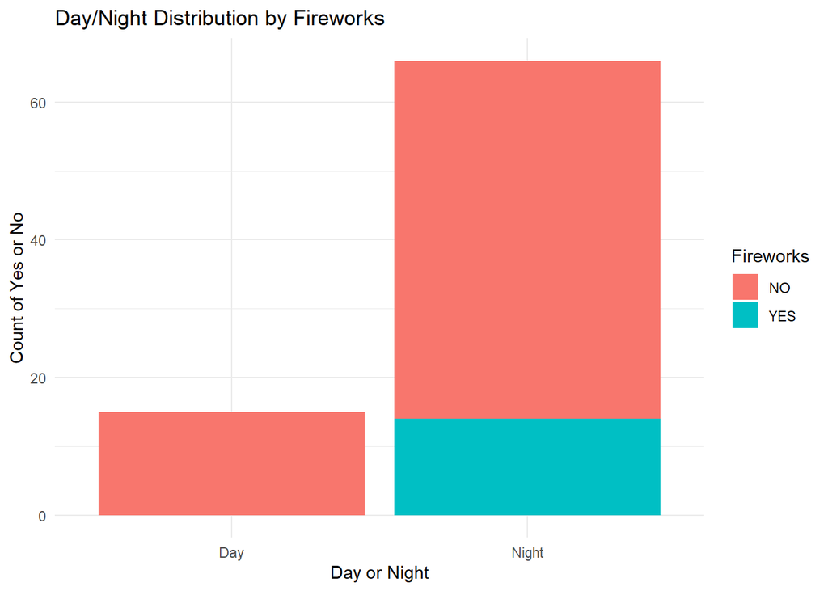

```r
ggplot(d, aes(x = day_night, fill = fireworks)) +
  geom_bar(position = "stack") +
  labs(title = "Day/Night Distribution by Fireworks",
       x = "Day or Night",
       y = "Count of Yes or No",
       fill = "Fireworks") +
  theme_minimal()
```

## Regression - Multiple Linear Regression

By using the intuition developed from the previous section, a linear regression algorithm will be used by involving all variables inside the dataset to the task. Main goal of this implementation is to develop a good predictor that the data can be fit with low MSE.

Initially a conventional multi-regression will be applied by using all of the variables without any dataset manipulation.

```r
lmod <- lm(attend ~ ., data = d)
summary(lmod)
```

```
##
## Call:
## lm(formula = attend ~ ., data = d)
##
## Residuals:
##     Min      1Q  Median      3Q     Max
## -9300.2 -3166.2   -60.2  1387.1 12599.9
##
## Coefficients:
##                       Estimate Std. Error t value Pr(>|t|)
## (Intercept)           48472.69   14157.72   3.424  0.00135 **
## monthMAY               4292.17    6171.24   0.696  0.49039
## monthJUN              -3401.85   12098.49  -0.281  0.77989
## monthJUL               4195.67    6228.54   0.674  0.50408
## monthAUG               8003.27    7716.68   1.037  0.30534
## monthSEP               3505.86    7740.31   0.453  0.65282
## monthOCT               5434.11    9589.49   0.567  0.57382
## day                     133.64     141.28   0.946  0.34937
## day_of_weekTuesday     8674.11    2944.00   2.946  0.00513 **
## day_of_weekWednesday     13.24    2765.42   0.005  0.99620
## day_of_weekThursday     525.39    3906.85   0.134  0.89364
## day_of_weekFriday    -18253.57    9216.71  -1.980  0.05392 .
## day_of_weekSaturday    3688.89    3341.26   1.104  0.27558
## day_of_weekSunday       830.09    4819.11   0.172  0.86403
## opponentAstros       -20871.31   14215.14  -1.468  0.14915
## opponentBraves       -18977.73   13742.73  -1.381  0.17428
## opponentBrewers      -22827.23   15163.65  -1.505  0.13937
## opponentCardinals    -12986.02   13157.20  -0.987  0.32904
## opponentCubs         -10795.01   12633.90  -0.854  0.39749
## opponentGiants       -17279.00   13263.05  -1.303  0.19942
## opponentMarlins      -19335.74   13901.01  -1.391  0.17123
## opponentMets          -4492.43    6422.73  -0.699  0.48795
## opponentNationals     -6543.71   13941.96  -0.469  0.64113
## opponentPadres       -11480.11   11321.49  -1.014  0.31612
## opponentPhillies     -13922.32   12598.96  -1.105  0.27515
## opponentPirates      -12835.96   13339.19  -0.962  0.34117
## opponentReds         -16654.40   11914.66  -1.398  0.16918
## opponentRockies      -17348.59   12957.53  -1.339  0.18749
## opponentSnakes       -20268.77   12731.38  -1.592  0.11854
## opponentWhite Sox      -971.86    5734.64  -0.169  0.86620
## temp                     16.35     442.68   0.037  0.97071
## skiesCloudy            -108.12    2387.21  -0.045  0.96408
## day_nightNight        -3520.45    3582.79  -0.983  0.33118
## capYES                -6534.52    5873.33  -1.113  0.27193
## shirtYES                987.69    4600.00   0.215  0.83098
## fireworksYES          20183.54    8355.16   2.416  0.01992 *
## bobbleheadYES          9349.21    3198.32   2.923  0.00545 **
## ---
## Signif. codes:  0 '***' 0.001 '**' 0.01 '*' 0.05 '.' 0.1 ' ' 1
##
## Residual standard error: 5979 on 44 degrees of freedom
## Multiple R-squared:  0.7144, Adjusted R-squared:  0.4808
## F-statistic: 3.057 on 36 and 44 DF,  p-value: 0.0002493
```

A good application can be using a nonlinear transformation on the temperature feature since it has a nonlinear relationship with the attendance ratios which can be seen in the “Attendance vs Temperature” plot given above. The following relationship can be used for the transformation.

$$temp_{aug} = \sqrt{\large| temp - 24\large|}$$

```r
d_aug1 <- d
d_aug1$n_temp <- sqrt(abs(d_aug1$temp-24))
```

The new resultant feature and its relationship with the attendance is shown below

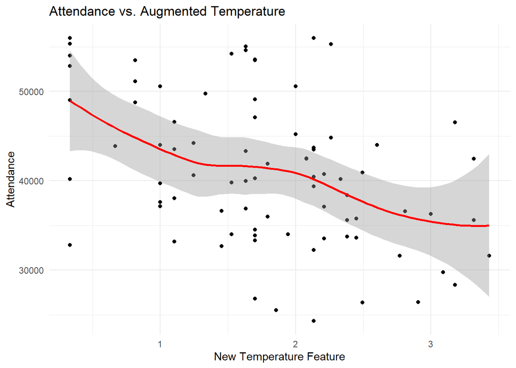

```r
ggplot(d_aug1, aes(x = n_temp, y = attend)) +
  geom_point(color = "black") +
  geom_smooth(formula = y ~ x, method = "loess", color = "red") +
  labs(title = "Attendance vs. Augmented Temperature", x = "New Temperature Feature", y = "Attendance") +
  theme_minimal()
```

```r
lmod2 <- lm(attend ~ ., data = d_aug1)
summary(lmod2)
```

```
##
## Call:
## lm(formula = attend ~ ., data = d_aug1)
##
## Residuals:
##      Min       1Q   Median       3Q      Max
## -11547.0  -3183.6   -284.4   1508.9  11827.5
##
## Coefficients:
##                       Estimate Std. Error t value Pr(>|t|)
## (Intercept)           58999.40   15319.91   3.851 0.000386 ***
## monthMAY                -70.16    6620.72  -0.011 0.991594
## monthJUN              -8483.77   12276.91  -0.691 0.493258
## monthJUL              -2645.67    7411.99  -0.357 0.722879
## monthAUG               2290.35    8343.78   0.274 0.785017
## monthSEP              -1013.72    8086.40  -0.125 0.900822
## monthOCT               2133.29    9627.63   0.222 0.825689
## day                      94.69     140.72   0.673 0.504599
## day_of_weekTuesday     7120.48    3042.44   2.340 0.023973 *
## day_of_weekWednesday  -1050.01    2791.54  -0.376 0.708663
## day_of_weekThursday     -36.66    3850.36  -0.010 0.992447
## day_of_weekFriday    -19832.33    9098.59  -2.180 0.034801 *
## day_of_weekSaturday    3732.39    3279.86   1.138 0.261433
## day_of_weekSunday       -94.88    4764.21  -0.020 0.984203
## opponentAstros       -21099.69   13954.18  -1.512 0.137831
## opponentBraves       -22637.95   13674.78  -1.655 0.105114
## opponentBrewers      -25531.71   14976.42  -1.705 0.095449 .
## opponentCardinals    -14937.12   12970.18  -1.152 0.255828
## opponentCubs         -14762.16   12637.14  -1.168 0.249180
## opponentGiants       -20811.80   13197.50  -1.577 0.122137
## opponentMarlins      -20821.95   13675.46  -1.523 0.135185
## opponentMets          -8368.02    6736.58  -1.242 0.220904
## opponentNationals    -13273.44   14292.58  -0.929 0.358232
## opponentPadres       -14982.08   11318.19  -1.324 0.192592
## opponentPhillies     -13592.48   12368.70  -1.099 0.277909
## opponentPirates      -16276.16   13262.11  -1.227 0.226399
## opponentReds         -18424.38   11745.48  -1.569 0.124063
## opponentRockies      -19085.29   12763.42  -1.495 0.142137
## opponentSnakes       -22427.74   12566.79  -1.785 0.081369 .
## opponentWhite Sox     -3264.20    5801.54  -0.563 0.576599
## temp                    115.17     438.73   0.263 0.794174
## skiesCloudy             183.11    2350.05   0.078 0.938256
## day_nightNight        -3524.76    3516.84  -1.002 0.321829
## capYES                -4138.06    5949.13  -0.696 0.490439
## shirtYES               -236.93    4577.20  -0.052 0.958958
## fireworksYES          21872.23    8266.33   2.646 0.011334 *
## bobbleheadYES          9022.91    3145.80   2.868 0.006372 **
## n_temp                -2628.18    1609.72  -1.633 0.109836
## ---
## Signif. codes:  0 '***' 0.001 '**' 0.01 '*' 0.05 '.' 0.1 ' ' 1
##
## Residual standard error: 5869 on 43 degrees of freedom
## Multiple R-squared:  0.7311, Adjusted R-squared:  0.4997
## F-statistic: 3.159 on 37 and 43 DF,  p-value: 0.0001792
```

From the results it can be seen that the residual standard error has been decreased to 5869 and statistical significance of the new temperature variable has increased which can be seen from the “t-test” values. The t probability has decreased to 0.1 from 0.97.

```r
d_aug2 <- d_aug1
d_aug2$summer = ifelse(d_aug1$month %in% c("JUN", "JUL", "AUG"), 1, 0)
d_aug2 <- d_aug2[, -which(names(d_aug2) %in% c("month"))]
```

```r
lmod3 <- lm(attend ~ ., data = d_aug2)
summary(lmod3)
```

```
##
## Call:
## lm(formula = attend ~ ., data = d_aug2)
##
## Residuals:
##      Min       1Q   Median       3Q      Max
## -11932.4  -2922.1   -210.6   1700.6  11927.5
##
## Coefficients:
##                       Estimate Std. Error t value   Pr(>|t|)
## (Intercept)           47889.48    8578.99   5.582 0.00000108 ***
## day                      25.74     107.84   0.239    0.81234
## day_of_weekTuesday     7388.12    2874.17   2.571    0.01331 *
## day_of_weekWednesday   -305.41    2623.65  -0.116    0.90782
## day_of_weekThursday     370.92    3590.40   0.103    0.91815
## day_of_weekFriday    -18857.24    8732.05  -2.160    0.03583 *
## day_of_weekSaturday    3729.02    3108.15   1.200    0.23612
## day_of_weekSunday      1090.21    3914.57   0.279    0.78182
## opponentAstros        -9773.52    5823.47  -1.678    0.09979 .
## opponentBraves       -11579.38    5771.58  -2.006    0.05048 .
## opponentBrewers      -13342.58    6369.18  -2.095    0.04148 *
## opponentCardinals     -4345.49    5712.04  -0.761    0.45052
## opponentCubs          -3128.84    6289.38  -0.497    0.62112
## opponentGiants        -8749.91    5097.63  -1.716    0.09252 .
## opponentMarlins       -8131.16    5611.04  -1.449    0.15380
## opponentMets          -4956.55    5578.45  -0.889    0.37869
## opponentNationals     -1464.92    6314.88  -0.232    0.81754
## opponentPadres        -5903.48    4732.49  -1.247    0.21829
## opponentPhillies      -6373.15    5149.76  -1.238    0.22190
## opponentPirates       -6185.81    5618.20  -1.101    0.27637
## opponentReds         -11987.53    6539.38  -1.833    0.07299 .
## opponentRockies       -7980.03    4972.36  -1.605    0.11508
## opponentSnakes       -11850.10    4826.97  -2.455    0.01776 *
## opponentWhite Sox     -2077.63    5508.14  -0.377    0.70769
## temp                     63.54     200.45   0.317    0.75264
## skiesCloudy              93.48    2183.41   0.043    0.96603
## day_nightNight        -2850.69    2984.36  -0.955    0.34426
## capYES                -4566.64    5671.86  -0.805    0.42471
## shirtYES                605.79    4336.03   0.140    0.88947
## fireworksYES          21105.77    7945.06   2.656    0.01069 *
## bobbleheadYES          9581.08    2934.64   3.265    0.00202 **
## n_temp                -2008.05    1304.65  -1.539    0.13034
## summer                 1687.09    2628.79   0.642    0.52407
## ---
## Signif. codes:  0 '***' 0.001 '**' 0.01 '*' 0.05 '.' 0.1 ' ' 1
##
## Residual standard error: 5665 on 48 degrees of freedom
## Multiple R-squared:  0.7203, Adjusted R-squared:  0.5338
## F-statistic: 3.863 on 32 and 48 DF,  p-value: 0.00001246
```

As it can be seen the prediction accuracy has further increased by reducing the residual standard error to 5665. Similar operations can be applied on the features in order to increase the prediction accuracy. Comparison of the models can be done using the Analysis of Variance (ANOVA)

```r
sum <- anova(lmod,lmod2,lmod3)
sum
```

```
## Analysis of Variance Table
##
## Model 1: attend ~ month + day + day_of_week + opponent + temp + skies +
##     day_night + cap + shirt + fireworks + bobblehead
## Model 2: attend ~ month + day + day_of_week + opponent + temp + skies +
##     day_night + cap + shirt + fireworks + bobblehead + n_temp
## Model 3: attend ~ day + day_of_week + opponent + temp + skies + day_night +
##     cap + shirt + fireworks + bobblehead + n_temp + summer
##   Res.Df        RSS Df Sum of Sq      F Pr(>F)
## 1     44 1572994766
## 2     43 1481172940  1  91821825 2.6657 0.1098
## 3     48 1540623750 -5 -59450810 0.3452 0.8825
```

The model “lmod2” is selected as the best linear regression model and the performance will be evaluated accordingly.

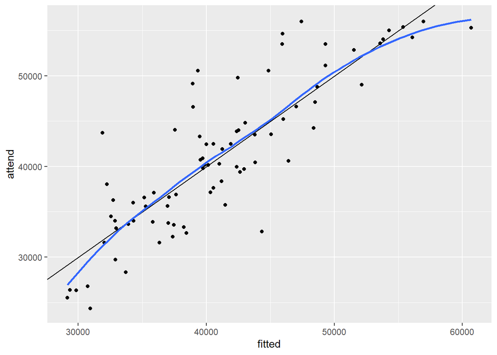

```r
d_aug1 %>%
  mutate(fitted = fitted(lmod2)) %>%
  ggplot(aes(fitted, attend)) +
  geom_point() +
  geom_abline() +
  geom_smooth(se=FALSE)
```

```r
confint(lmod2, c("bobbleheadYES","shirtYES","capYES","fireworksYES"))
```

```
##                    2.5 %    97.5 %
## bobbleheadYES   2678.793 15367.027
## shirtYES       -9467.730  8993.879
## capYES        -16135.630  7859.515
## fireworksYES    5201.589 38542.878
```

## Conclusion

In conclusion, the dataset is evaluated using various combinations of attributes to uncover any relationships. Furthermore, many sorts of plots are utilized to apply the techniques learned in the course. We can see that some relationships are better represented with certain types of plots. It has been demonstrated that an arbitrary number of different linear regression models may be employed to forecast the provided dataset. The linear model with the updated temperature component outperformed the others that were examined. A thorough regression analysis was performed on the provided dataset, and the concepts of chi-squared test, multiple linear regression, ANOVA, and confidence intervals have been understood.